# Practicals — Introduction to Bayesian analysis for medical studies — Solutions to exercise 6

Boris Hejblum

May 15<sup>th</sup> 2019

# Exercise 6: Bayesian meta-analysis

In 2014, Crins *et al.* published a meta-analysis assessing the incidence of acute rejection (AR) with or without Interleukin-2 receptor antagonists. In this exercise we will recreate this analysis.

0. Load the `R` package `bayesmeta` (Röver 2017) and the data from (Crins et al. 2014) with the `R` command `data("CrinsEtAl2014")`.

   ```r
   library(bayesmeta)
   data(CrinsEtAl2014)
   ```

1. Play around with the companion shiny app at: http://ams.med.uni-goettingen.de:3838/bayesmeta/app/. Explore and comment the results and the outputs, try out different options and priors, etc.
2. Within `R` now, using the `escalc()` function from the package `metafor`, compute the estimated *log odds ratios* from the 6 considered studies alongside their sampling variances (**ProTip:** read the *Measures for Dichotomous Variables* section from the help of the `escalc()` function). Check that those are the same as the one on the online *shiny app* (**ProTip:** ‘sigma’ is the stantard error, i.e. the square root of the sampling variance `vi`)

   ```r
   library("metafor")
   crins.es <- escalc(measure = "OR", ai = exp.AR.events, n1i = exp.total, ci = cont.AR.events,
       n2i = cont.total, slab = publication, data = CrinsEtAl2014)
   crins.es[, c("publication", "yi", "vi")]
   ```

   | publication | yi | vi |
   | --- | --- | --- |
   | Heffron (2003) | -2.3097026 | 0.3593718 |
   | Gibelli (2004) | -0.4595323 | 0.3095760 |
   | Schuller (2005) | -2.3025851 | 0.7750000 |
   | Ganschow (2005) | -1.7578579 | 0.2078161 |
   | Spada (2006) | -1.2584610 | 0.4121591 |
   | Gras (2008) | -2.4178959 | 2.3372623 |

   Log odds ratios are symmetric around zero and have a sampling distributions closer to the normal distibution than the natural OR scale. They are usually prefered for meta-analyses. Their sample variance is computed as the sum of the inverse of all the counts in the $2 \times 2$ associated contingency table (Fleiss and Berlin 2009).
3. Perform a random-effect meta-analysis of those data using the `bayesmeta()` function from the `R` package `bayesmeta`, within `R`. Use a uniform prior on $[0,4]$ for $\tau$ and a Gaussain prior for $\mu$ centered around 0 and with a standard deviation of 4.

   ```r
   res_crins_bayesmeta <- bayesmeta(y = crins.es$yi, sigma = crins.es$vi, labels = crins.es$publication,
       tau.prior = function(t) {
           dunif(t, max = 4)
       }, mu.prior = c(0, 4), interval.type = "central")
   summary(res_crins_bayesmeta)
   ```

   ```
   ##  'bayesmeta' object.
   ## data (6 estimates):
   ##                          y     sigma
   ## Heffron (2003)  -2.3097026 0.3593718
   ## Gibelli (2004)  -0.4595323 0.3095760
   ## Schuller (2005) -2.3025851 0.7750000
   ## Ganschow (2005) -1.7578579 0.2078161
   ## Spada (2006)    -1.2584610 0.4121591
   ## Gras (2008)     -2.4178959 2.3372623
   ##
   ## tau prior (proper):
   ## function(t) {
   ##         dunif(t, max = 4)
   ##     }
   ## <bytecode: 0x7f822c079f10>
   ##
   ## mu prior (proper):
   ## normal(mean=0, sd=4)
   ##
   ## ML and MAP estimates:
   ##                    tau        mu
   ## ML joint     0.5807934 -1.553422
   ## ML marginal  0.6706741 -1.551747
   ## MAP joint    0.5800931 -1.543907
   ## MAP marginal 0.6706835 -1.541104
   ##
   ## marginal posterior summary:
   ##                 tau         mu      theta
   ## mode      0.6706835 -1.5411041 -1.5326574
   ## median    0.8598200 -1.5571013 -1.5545203
   ## mean      0.9948322 -1.5652306 -1.5652306
   ## sd        0.5558042  0.5172797  1.2531587
   ## 95% lower 0.3151042 -2.6376511 -4.1622544
   ## 95% upper 2.5077819 -0.5296971  0.9920784
   ##
   ## (quoted intervals are central, equal-tailed credible intervals.)
   ##
   ## Bayes factors:
   ##               tau=0      mu=0
   ## actual  0.036709997 0.1523511
   ## minimum 0.008531533 0.0141887
   ##
   ## relative heterogeneity I^2 (posterior median): 0.8338231
   ```

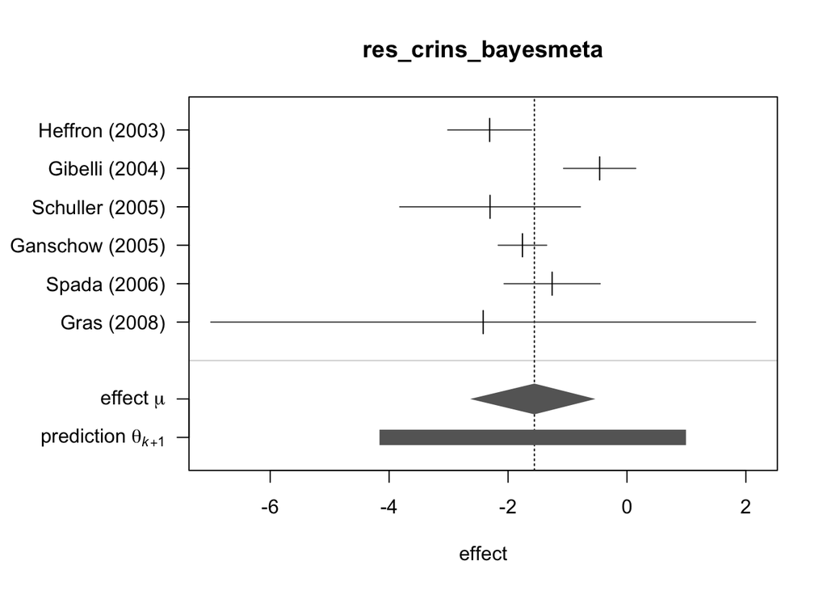

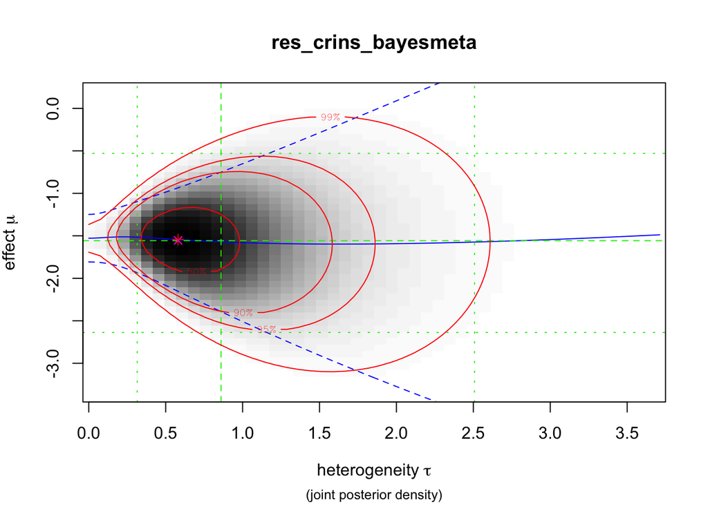

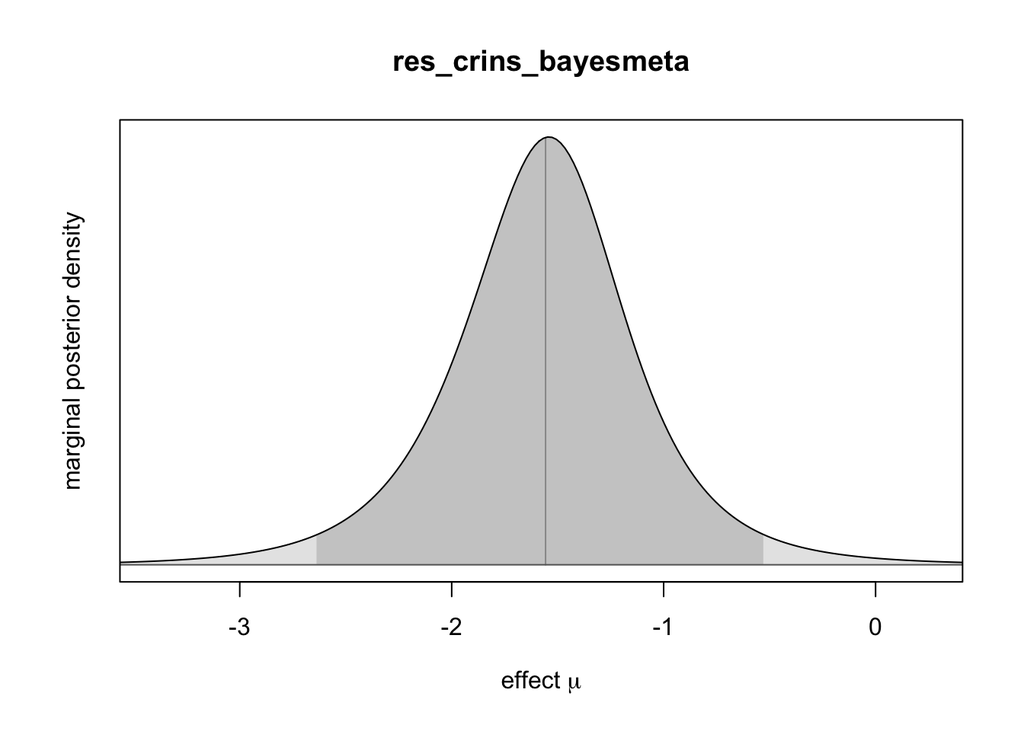

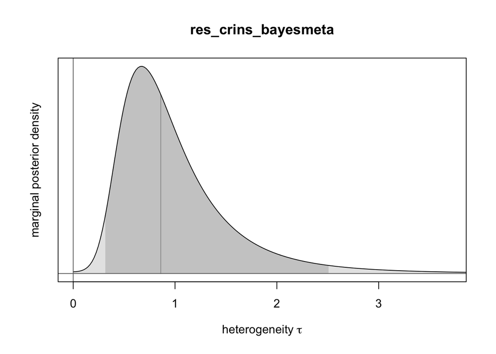

   ```r
   plot(res_crins_bayesmeta)
   ```

   ```
   # Random-effects model for Crins et al. 2014 Acute Rejection meta-analysis
   model{

     # Sampling model/likelihood
     for (i in 1:N){
       logOR[i] <- theta[i] + epsilon[i]
       epsilon[i]~dnorm(0, sigma.precision[i])
       theta[i]~dnorm(mu, precision.tau)
     }

     # Prior
     mu~dnorm(0, 0.0625) # 1/16 = 0.0625
     tau~dunif(0, 4)

     # Reparametrization
     for(i in 1:N){
       sigma.precision[i] <- pow(sigma[i], -2)
     }
     precision.tau <- pow(tau, -2)

   }
   ```

   ```r
   # Sampling
   library(rjags)
   crins_jags_res <- jags.model(file = "crinsBUGSmodel.txt", data = list(logOR = crins.es$yi,
       sigma = sqrt(crins.es$vi), N = length(crins.es$yi)), n.chains = 3)
   res_crins_jags_res <- coda.samples(model = crins_jags_res, variable.names = c("mu",
       "tau"), n.iter = 20000)

   # Postprocessing
   res_crins_jags_res <- window(res_crins_jags_res, start = 5001)  # remove burn-in for Markov chain convergence
   summary(res_crins_jags_res)
   ```

   ```
   ##
   ## Iterations = 5001:21000
   ## Thinning interval = 1
   ## Number of chains = 3
   ## Sample size per chain = 16000
   ##
   ## 1. Empirical mean and standard deviation for each variable,
   ##    plus standard error of the mean:
   ##
   ##        Mean     SD Naive SE Time-series SE
   ## mu  -1.5946 0.4649 0.002122       0.003684
   ## tau  0.7434 0.5533 0.002525       0.010717
   ##
   ## 2. Quantiles for each variable:
   ##
   ##         2.5%     25%    50%     75%   97.5%
   ## mu  -2.54870 -1.8460 -1.593 -1.3340 -0.6689
   ## tau  0.05264  0.3534  0.627  0.9881  2.1883
   ```

   ```r
   HDInterval::hdi(res_crins_jags_res)
   ```

   ```
   ##               mu         tau
   ## lower -2.5621034 0.001024016
   ## upper -0.6831132 1.808254414
   ## attr(,"credMass")
   ## [1] 0.95
   ```

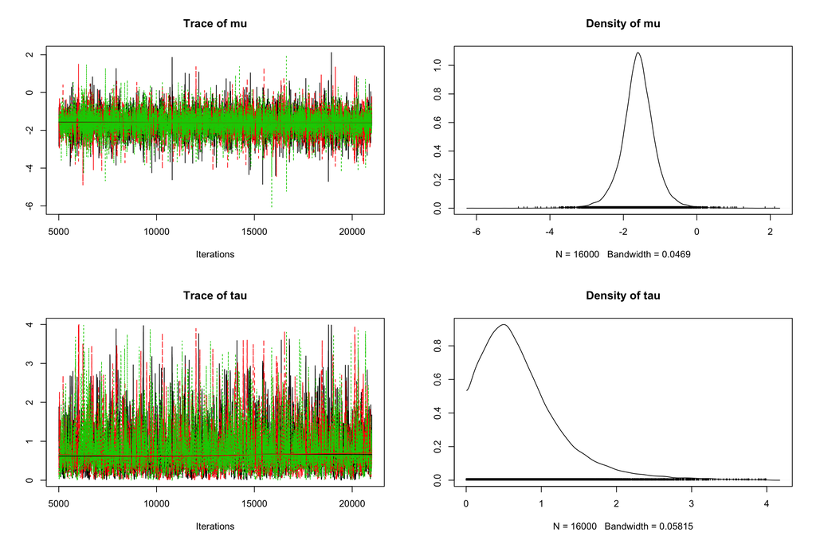

   ```r
   plot(res_crins_jags_res)
   ```

# Bibliography

Crins, Nicola D., Christian Röver, Armin D. Goralczyk, and Tim Friede. 2014. “Interleukin-2 Receptor Antagonists for Pediatric Liver Transplant Recipients: A Systematic Review and Meta-Analysis of Controlled Studies.” *Pediatric Transplantation* 18 (8): 839–50. https://doi.org/10.1111/petr.12362.

Fleiss, Joseph L., and Jesse A. Berlin. 2009. “Effect Sizes for Dichotomous Data.” In *The Handbook of Research Synthesis and Meta-Analysis, 2nd Ed*, 237–53. New York, NY, US: Russell Sage Foundation.

Röver, Christian. 2017. “Bayesian Random-Effects Meta-Analysis Using the Bayesmeta R Package.” *arXiv Preprint 1711.08683*. http://www.arxiv.org/abs/1711.08683.